# STSCI 4100: IDMb Analysis Project

Tony Oh (do256), William Rhee (wr86)

2025-03-25

| **TABLE OF CONTENTS** |
| --- |
| **1. Introduction** |
| **2. Data Exploration** |
| *The basics dataset* |
| *The crew dataset* |
| *The principals dataset* |
| *A side-note* |
| *The ratings dataset* |
| **3. Data Analysis** |
| *Question 1* |
| *Question 2* |
| *Question 3* |
| *Question 4* |
| **4. Summary** |

# [1] INTRODUCTION:

IMDb documents reviews of released movies and films in non-commercial datasets — these datasets contain vast amounts of metadata regarding viewer ratings, genres, release years, and more. In this project, we want to understand if these factors dictate any trends in film popularity and genre success.

In this project, we will be using four datasets from IMDb:

1. **title.basics.tsv**: A dataset providing all the basic details about a broad range of films from 1892 to 2026.
2. **title.crew.tsv**: A dataset providing the ID’s specifically of the director and writers for the movies from Dataset 1.
3. **title.principals.tsv**: A dataset providing details about other crew (editors, producers, etc.) for the movies from Dataset 1.
4. **title.ratings.tsv**: A dataset that contains the rating data from IMDb’s users for the movies from Dataset 1,

Our analysis focuses on a **wide range of films** — from shorts, TV series, movies, and even video content — in the period **1892 to 2026**. We will be answering **four questions** to explore trends in ratings, creative roles, and genres across the whole IMDb dataset.

1. **Ratings**: Does the number of votes per film affect the ratings?
2. **Creative role (writer)**: Does having a writer affect the ratings?
3. **Actor roles**: Does having certain actors have an affect on ratings?
4. **Genres**: Which genres get the highest ratings?

That being said, let’s start with data exploration.

# [2] DATA EXPLORATION:

There are four points in this section:

1. Importing the Datasets.
2. A Quick Glance.
3. Specific Breakdowns.
4. Combining the Datasets.

## [A] Importing the datasets.

```r
library(data.table)
gc() # Clear unused memory
```

```
##           used (Mb) gc trigger (Mb) limit (Mb) max used (Mb)
## Ncells  622363 33.3    1423820 76.1         NA   900675 48.2
## Vcells 1180344  9.1    8388608 64.0      16384  1963523 15.0
```

```r
# setwd("~/Documents/06.sp25/04.stsci4100/stsci4100") # MODIFY TO CORRECT WD
```

```r
basics <- readRDS("rds/basics.rds");
crew <- readRDS("rds/crew.rds");
principals <- readRDS("rds/principals.rds");
ratings <- readRDS("rds/ratings.rds");

list.of.datasets <- list(basics, crew, principals, ratings)
attr(list.of.datasets, "names") <- c("basics", "crew", "principals", "ratings")
```

## [B] A Quick Glance.

```r
# Let's view our datasets.

list.heads = FALSE # Set to TRUE to view the heads of datasets
if (list.heads) {
  head(basics)
  head(crew)
  head(principals)
  head(ratings)
}

view.datasets = FALSE # Set to TRUE to view datasets
if (view.datasets) {
  View(basics)
  View(crew)
  View(principals)
  View(ratings)
}

# How many columns are in our datasets?
for (i in names(list.of.datasets)){
  column.names <- paste(colnames(list.of.datasets[[i]]), collapse = ", ")
  print(paste("In the", i, "dataset, there are", ncol(list.of.datasets[[i]]), "columns."))
  print(paste("Its columns are:", column.names))
  cat("\n")
}
```

```
## [1] "In the basics dataset, there are 9 columns."
## [1] "Its columns are: tconst, titleType, primaryTitle, originalTitle, isAdult, startYear, endYear, runtimeMinutes, genres"
##
## [1] "In the crew dataset, there are 3 columns."
## [1] "Its columns are: tconst, directors, writers"
##
## [1] "In the principals dataset, there are 6 columns."
## [1] "Its columns are: tconst, ordering, nconst, category, job, characters"
##
## [1] "In the ratings dataset, there are 3 columns."
## [1] "Its columns are: tconst, averageRating, numVotes"
```

```r
# How many rows are in our datasets?
for (i in 1:4) print(paste("There are", nrow(list.of.datasets[[i]]), "rows in the", names(list.of.datasets)[i], "dataset."))
```

```
## [1] "There are 200000 rows in the basics dataset."
## [1] "There are 200000 rows in the crew dataset."
## [1] "There are 200000 rows in the principals dataset."
## [1] "There are 200000 rows in the ratings dataset."
```

## [C] Specific Breakdowns.

### [C1] The basics dataset

The **basics** dataset:

- **tconst**: The unique id for a specific film.
- **titleType**: The kind of film — it can be a short, movie, tvShort, and more.
- **primaryTitle**: The final title of the film.
- **originalTitle**: The title of the film (before it was changed).
- **isAdult**: The indicator variable — 1 if it’s an adult film, 0 otherwise.
- **startYear**: The film’s release year.
- **endYear**: The film’s ending year, IF the film was a TV show (NA otherwise).
- **runtimeMinutes**: The film’s runtime (in minutes).
- **genres**: The film’s list of genres.

Here is a quick exploration of the **basics** dataset’s columns:

```r
anyNA(basics$tconst)                              # Investigating the column: tconst.
length(unique(basics$tconst)) == nrow(basics)

anyNA(basics$titleType)                           # Investigating the column: titleType.
unique(basics$titleType)

anyNA(basics$primaryTitle)                        # Investigating the column: primaryTitle.
length(unique(basics$primaryTitle))

anyNA(basics$originalTitle)                       # Investigating the column: originalTitle.
length(unique(basics$originalTitle))

anyNA(basics$isAdult)                             # Investigating the column: isAdult.
mean(basics$isAdult)

anyNA(basics$startYear)                           # Investigating the column: startYear.
min(basics$startYear, na.rm = TRUE)
max(basics$startYear, na.rm = TRUE)

anyNA(basics$endYear)                             # Investigating the column: endYear.
min(basics$endYear, na.rm = TRUE)
max(basics$endYear, na.rm = TRUE)

anyNA(basics$runtimeMinutes)                      # Investigating the column: runtimeMinutes.
min(basics$runtimeMinutes, na.rm = TRUE)
max(basics$runtimeMinutes, na.rm = TRUE)
mean(basics$runtimeMinutes, na.rm = TRUE)

anyNA(basics$genres)
```

Here are the takeaways from the given code:

- **tconst**: There are no missing values. There are exactly 200,000 id’s (i.e. individual films), one for every row.
- **titleType**: There are no missing values. There are 10 unique kinds of films in this dataset, ranging from shorts to video games.
- **primaryTitle**: There are no missing values. There are 179081 primaryTitles in the dataset (< 200,000). This should be looked into.
- **originalTitle**: There are no missing values. There are 182034 originalTitles in the dataset (< 200,000 and > 179081). This should be looked into.
- **isAdult**: There are no missing values. About 7% of all the films in the dataset are adult films. (OMG)
- **startYear**: There are missing values! Ignoring missing values, the earliest release date was 1892, while the most recent release date was 2025.
- **endYear**: There are missing values! Ignoring missing values, the earliest end date was 1945, while the most recent end date was 2026.
- **runtimeMinutes**: There are missing values! Ignoring missing values, the shortest film is a minute long, while the longest film is 1,620 minutes (27 hours) long. The average film length is around 75 minutes (1.25 hours).
- **genres**: There are missing values!

### [C2] The crew dataset

The **crew** dataset:

- **tconst**: The unique id for a specific film.
- **directors**: The film’s list of directors.
- **writers**: The film’s list of writers.

Here is a quick exploration of the **crew** dataset’s columns:

```r
anyNA(crew$tconst)                               # Investigating the column: tconst.
length(unique(crew$tconst)) == nrow(crew)

anyNA(crew$directors)                            # Investigating the column: directors.
anyNA(crew$writers)                              # Investigating the column: writers.
```

Here are the takeaways from the given code:

- **tconst**: There are no missing values. There are exactly 200,000 id’s (i.e. individual films), one for every row.
- **directors**: There are some missing values. This means not every movie in our data will have a specified director.
- **writers**: There are some missing values. This means not every movie in our data will have a specified writer.

### [C3] The principals dataset

The **principals** dataset:

- **tconst**: The unique id for a specific film.
- **ordering**: The order in credits, where 1 is the most important and 35 is least important.
- **nconst**: The unique id for a specific person such as an actor, director, and more.
- **category**: The role of a specific person such as an actor, director, and more.
- **job**: The job title such as a producer, editor, and more.
- **characters**: The character that a specific person has played as.

Here is a quick exploration of the **principals** dataset’s columns:

```r
anyNA(principals$tconst)                                    # Investigating the column: tconst.
length(unique(principals$tconst)) == nrow(principals)

anyNA(principals$ordering)                                  # Investigating the column: ordering.
unique(principals$ordering)

anyNA(principals$nconst)                                    # Investigating the column: nconst.

anyNA(principals$category)                                  # Investigating the column: category.
unique(principals$category)

anyNA(principals$job)                                       # Investigating the column: job.
# unique(principals$job)                                    # Do not run. Leave this commented out.

anyNA(principals$characters)                                # Investigating the column: characters.
# unique(principals$characters)                             # Do not run. Leave this commented out.
```

Here are the takeaways from the given code:

- **tconst**: There are no missing values. However, the number of unique film ID’s does not equal the number of rows — this is because upon close inspection, we can see that there are duplicated ID’s across several rows. This is different from the other three datasets, where there is one unique film ID for each row.
- **ordering**: There are no missing values. The ordering from most to least important ranges from 1 to 35.
- **nconst**: There are no missing values.
- **category**: There are no missing values. There are 12 unique categories in the dataset, from director to casting director.
- **job**: There are missing values — this is because of the duplicate values from the first column. There are too many unique values within this column for R to run through without crashing (several times).
- **characters**: There are missing values — this is because of the duplicate values from the first column. There are too many unique values within this column for R to run through without crashing (several times).

### A side-note

We know that there are 12 unique categories within the **category** column. We also know that the ordering ranges from 1 to 35, where 1 is most important and 35 is least important.

So as a SIDE-NOTE, let’s make a DataFrame (and plots) that count how many times each job **category** appears in a specific **ordering**.

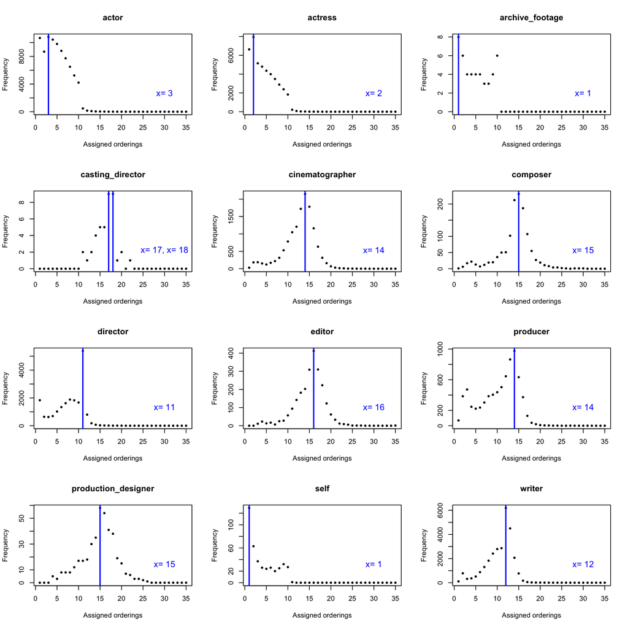

| category | ordering |
| --- | --- |
| actor | 3 |
| actress | 2 |
| archive_footage | 1 |
| casting_director | 17, 18 |
| cinematographer | 14 |
| composer | 15 |
| director | 11 |
| editor | 16 |
| producer | 14 |
| production_designer | 15 |

[output cut: 2 more lines]

As we can see, the code matches what we’d expect if we eyeball what the code is doing to **my.table**.

### [C4] The ratings dataset

The **ratings** dataset:

- **tconst**: The unique id for a specific film. There are exactly 200,000 id’s (i.e. individual films), one for every row.
- **averageRating**: The average rating, which was given to reviewers on a 1-10 scale.
- **numVotes**: The number of reviewers.

Here is a quick exploration of the **ratings** dataset’s columns:

```r
anyNA(ratings$tconst)                                    # Investigating the column: tconst.
length(unique(ratings$tconst)) == nrow(ratings)

anyNA(ratings$averageRating)                             # Investigating the column: averageRating.
unique(ratings$averageRating)
min(ratings$averageRating)
max(ratings$averageRating)
mean(ratings$averageRating)

anyNA(ratings$numVotes)                                  # Investigating the column: numVotes.
min(ratings$numVotes)
length(which(ratings$numVotes == min(ratings$numVotes)))
max(ratings$numVotes)
length(which(ratings$numVotes == max(ratings$numVotes)))
which(ratings$numVotes == max(ratings$numVotes))
```

Here are the takeaways from the given code:

- **tconst**: There are no missing values. There are exactly 200,000 id’s (i.e. individual films), one for every row.
- **averageRating**: There are no missing values.
- **numVotes**: There are no missing values. The worst review ever given was 1/10, while the best were 10/10. As a fun fact, the average rating across movies from the 1890’s all the way to present day is roughly 6/10. Of all 200000 films, 513 films have received the lowest number of reviews (only 5 reviews). Of all 200000 films, only one film (i.e. the film in the 84776th row) has the largest number of reviews (3026798 reviews).